# Copulas (General)

Tanishq Chauhan

4/30/2020

# Model Copulas

## Using Self Generated Data

This R-markdown book is for future self reference.

Generate n samples from a multivariate normal distribution of 3 random variables given the covariance matrix sigma using the MASS package.

```r
library(MASS)
set.seed(100)

m <- 3
n <- 2000
sigma <- matrix(c(1, 0.4, 0.2,
                  0.4, 1, -0.8,
                  0.2, -0.8, 1),
                nrow=3)
z <- mvrnorm(n,mu=rep(0, m),Sigma=sigma,empirical=T)
```

Check the samples correlation using cor() and a pairplot. Set method=‘spearman’ in order to use Spearman’s Rho instead of the ‘pearson’ method in the cor() function.

```r
library(psych)
cor(z,method='spearman')
```

```
##           [,1]       [,2]       [,3]
## [1,] 1.0000000  0.3812244  0.1937548
## [2,] 0.3812244  1.0000000 -0.7890814
## [3,] 0.1937548 -0.7890814  1.0000000
```

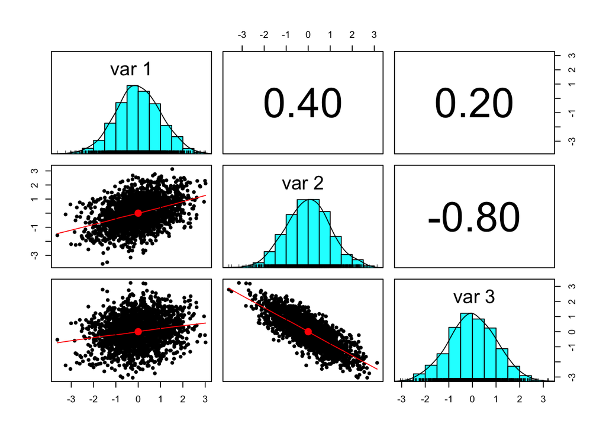

```r
pairs.panels(z)
```

Many empirical evidence have skewed or heavy tailed marginals. What if we would like to create a similar correlated random variables but with arbitrary marginals, say, a Gamma(2,1), a Beta(2,2), and a t($v$=5) distribution?

Here’s a possible algorithm to do that:

1. Generate the variables $x_i$ from a Gaussian multivariate (as we did)
2. Remembering the probability integral transformation:

   $X∼FX⇒U=FX(X)∼U(0,1)$

transform $xi$ using the Gaussian cdf, $Φ$ (in R is called pnorm), $u_i=Φ(x_i)$, where ui have marginal uniform distributions but are still correlated as variables $x_i$.

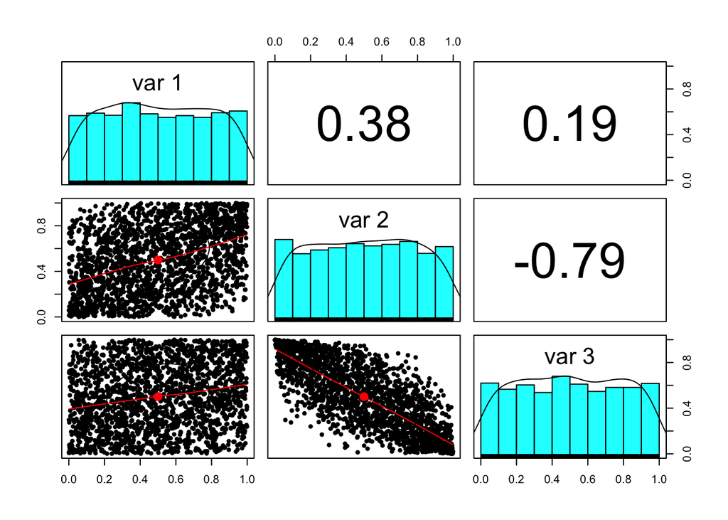

```r
u <- pnorm(z)
pairs.panels(u)
```

3. Apply, for each variable $ui_$, the inverse cdf of the required distribution that we wish as the marginal (eg, in R, the inverse of pnorm is qnorm), that is $z_i=F^{-1}(u_i)$:

```r
library(rgl)
plot3d(u[,1],u[,2],u[,3],pch=20,col='navyblue')
```

And we see that now the marginals have the distributions we wanted!

```r
x1 <- qgamma(u[,1],shape=2,scale=1)
x2 <- qbeta(u[,2],2,2)
x3 <- qt(u[,3],df=5)
plot3d(x1,x2,x3,pch=20,col='blue')
```

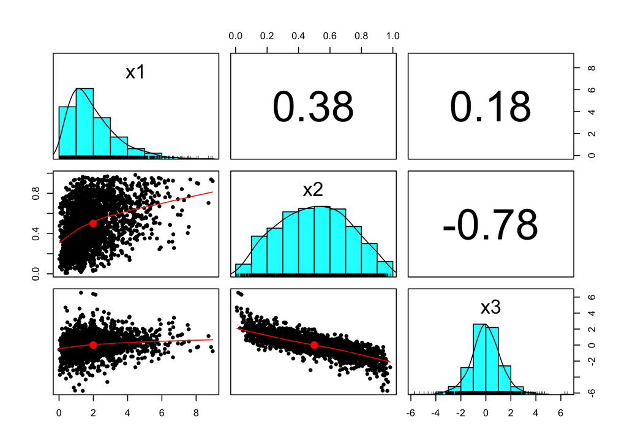

```r
df <- cbind(x1,x2,x3)
pairs.panels(df)
```

```r
cor(df,meth='spearman')
```

```
##           x1         x2         x3
## x1 1.0000000  0.3812244  0.1937548
## x2 0.3812244  1.0000000 -0.7890814
## x3 0.1937548 -0.7890814  1.0000000
```

## Using the `Copula` package

This process can also be coded using package `copula`:

```r
library(copula)
set.seed(100)
myCop <- normalCopula(param=c(0.4,0.2,-0.8), dim = 3, dispstr = "un")
myMvd <- mvdc(copula=myCop, margins=c("gamma", "beta", "t"),
              paramMargins=list(list(shape=2, scale=1),
                                list(shape1=2, shape2=2),
                                list(df=5)) )
```

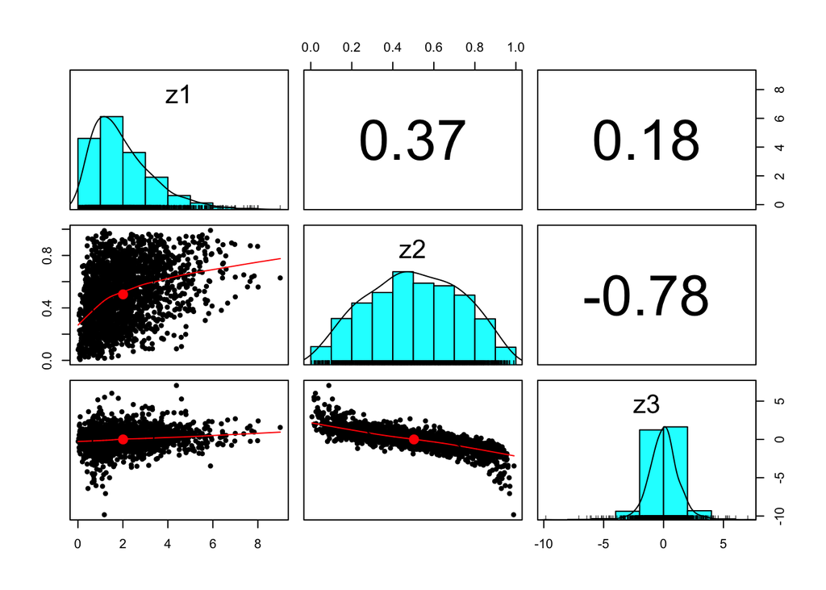

```r
z2 <- rMvdc(n, myMvd)
colnames(z2) <- paste0("z",1:m)
pairs.panels(z2)
```

## Copulas

A **copula** (from the Latin: link, bond) is a multivariate distribution function with standard uniform marginal distributions. More formally, if $(X,Y)$ is a pair of continuous rv’s, with joint $H(x,y)$ and marginals $F_X(x),F_Y(y)$, then a copula is the distribution function $C:[0,1]^{2}→[0,1]$,

$C(u,v)=H(F^{−1}_X(u),F^{−1}_Y(v))$

where $U=F_X(x)∼U(0,1), V=F_Y(y)∼U(0,1)$.

Copulas are interesting because they can couple a multivariate distribution to arbitrary marginal distributions, being more flexible that the standard elliptical distributions. They contain all the information about (ie, they model) the dependence between all $d$ random variables.

The copula function assigns a non-negative number to each hyper-rectangle in $[0,1]^{n}$.

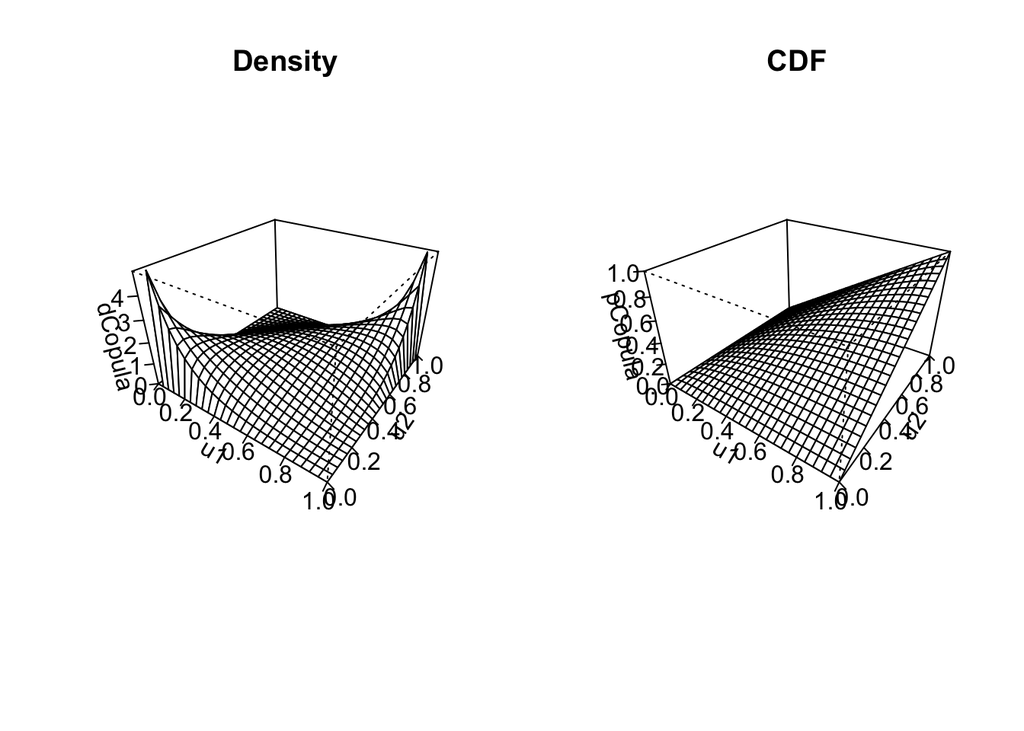

```r
cop2 <- normalCopula(param=c(0.7), dim=2, dispstr="un") # 2D copula to plot
par(mfrow=c(1,2))
persp(cop2, dCopula, main="Density", xlab="u1", ylab="u2", theta=35)
persp(cop2, pCopula, main="CDF",     xlab="u1", ylab="u2", theta=35)
```

The next plot shows an independent copula $C(u_1,u_2)=u_1u_2$,

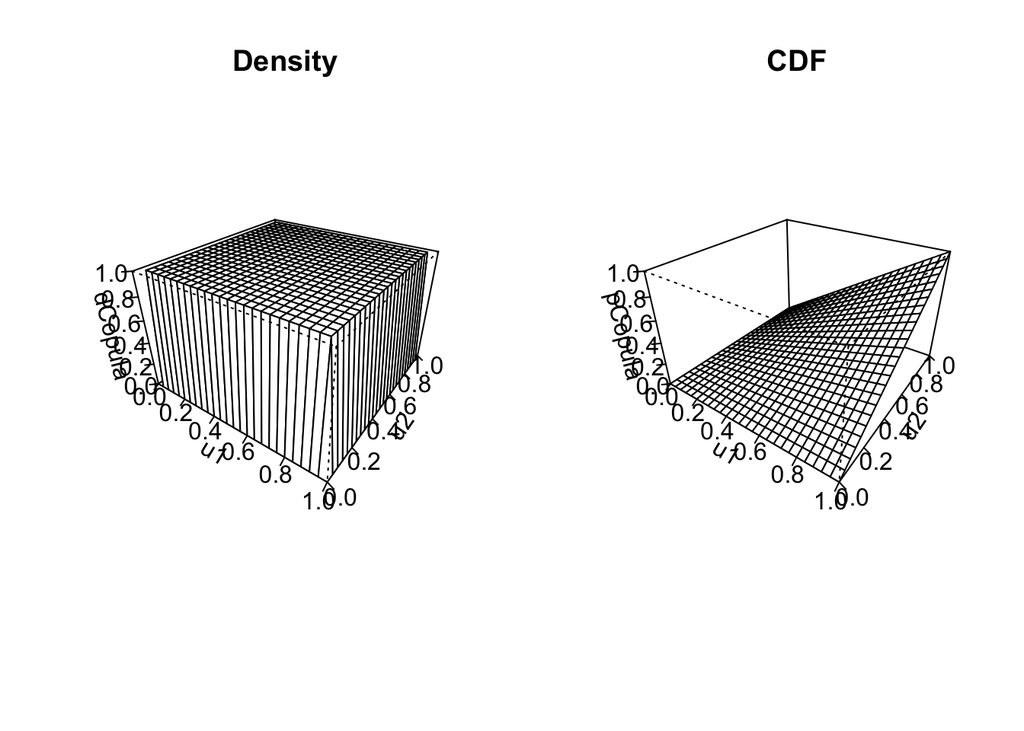

```r
ind.cop <- indepCopula(dim = 2)
par(mfrow=c(1,2))
persp(ind.cop, dCopula, main="Density", xlab="u1", ylab="u2", theta=35)
persp(ind.cop, pCopula, main="CDF",     xlab="u1", ylab="u2", theta=35)
```

**Sklar’s Theorem** states that given a d-dimensional joint distribution $H$ with marginals $F_1$ and $F_d$, then there exists a copula $C$ such that

$H(u_1,…,u_d)=C(F_1(u_1),…,F_d(u_d))$

Also, for any univariates $F_1…F_d$, and any copula $C$, the function $H$ is a d-dimensional distribution with marginals $F_1…F_d$. If $F_1…F_d$ are continuous, then $C$ is unique. So, a joint distribution can be split into marginals and a copula, which can be studied separately. Also, with a copula, we can create many different joint distributions by selecting different marginals. This is what `copula::mvdc()` does.

## Archimedean Copulas

Archimedean Copulas are a specific type of copula with format

$C(u_1,u_2)=g^{[-1]}(g(u_1)+g(u_2))$

where $g:[0,1]→[0,∞),g(1)=0$ is called the copula generator, and $g^{[−1]}(x)$ is a pseudo-inverse, which is $g^{−1}(x)$ if $0≤t≤g(0)$ and zero otherwise.

These copulas are continuous, strictly decreasing, convex, commutative ($C(u_1,u_2)=C(u_2,u_1))$, and associate ($C(u_1,C(u_2,u_3))=C(C(u_1,u_2),u_3)$). These properties make them good tools for applications.

An eg is the Gumbel copula,

$Cη(u,v)=exp{−((−logu)^{η}+(−logv)^{η})^{1/η}}$

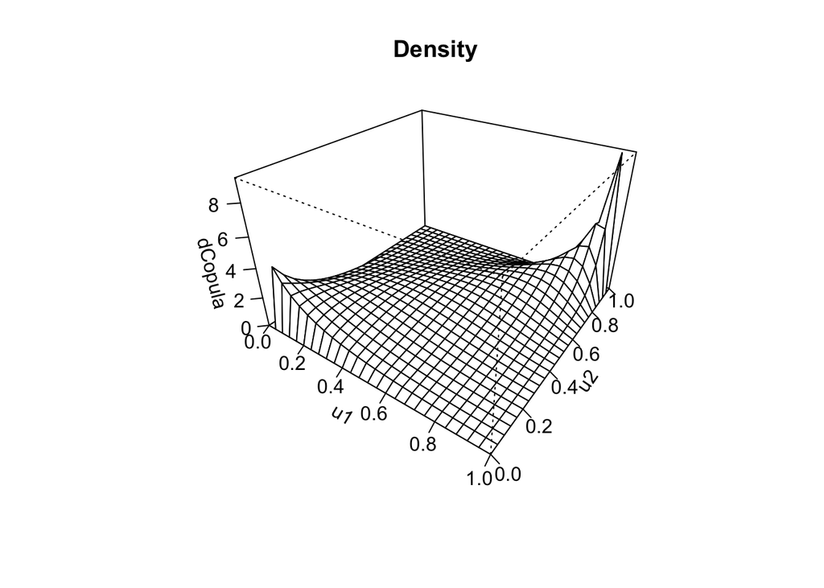

```r
gumbel.cop <- gumbelCopula(param=2, dim=2)  # gumbel copula with parameter eta=2

persp(gumbel.cop, dCopula, main="Density", xlab="u1", ylab="u2", theta=35)
```

## Parameter Estimation

Let’s create a dataset

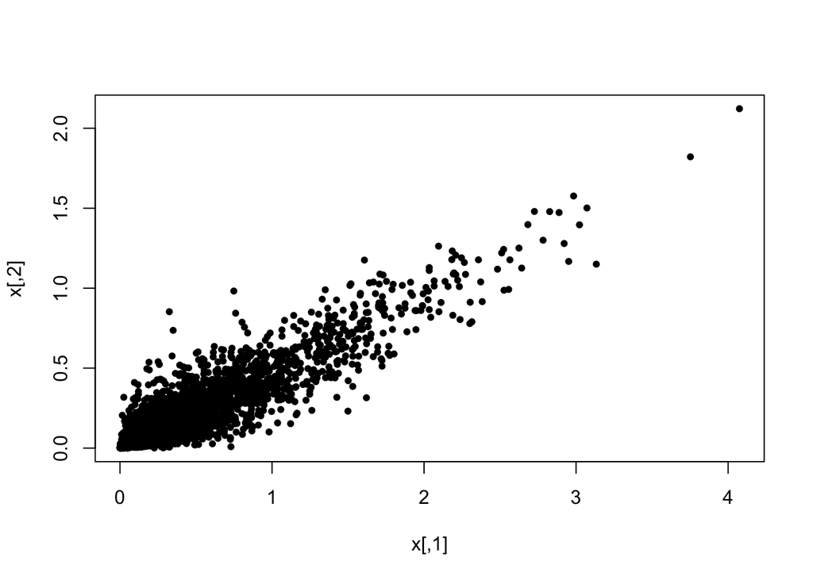

```r
gumbel.cop <- gumbelCopula(param=3, dim=2)
gMvd2 <- mvdc(gumbel.cop, c("exp","exp"),  # we'll assume this copula is unkonwn
              list(list(rate=2), list(rate=4)))
set.seed(11)
x <- rMvdc(2500, gMvd2)
plot(x, pch=20)
```

…and try to find the copula and the marginals that model this dataset.

If we knew the type of copula and type of margins, we just fit the parameters of a copula to the data (herein, we use the same copula object that created the dataset, something we will not have the luxury to have in a real application).

```r
fit2 <- fitMvdc(x, gMvd2, start = c(1,1,2), hideWarnings=FALSE)
print(fit2)     # fit2@mvdc returns the fitted multivariate distribution
```

```
## Call: fitMvdc(data = x, mvdc = gMvd2, start = c(1, 1, 2), hideWarnings = FALSE)
## Maximum Likelihood estimation based on 2500 2-dimensional observations.
## Copula:  gumbelCopula
## Margin 1 :
## m1.rate
##   1.944
## Margin 2 :
## m2.rate
##   3.954
## Copula:
## alpha
## 3.041
## The maximized loglikelihood is 1956
## Optimization converged
```

```r
fit2@estimate
```

```
## [1] 1.943978 3.954362 3.040675
```

More generally, if we don’t know the format of the copula neither the marginals, with package `VineCopula` we can estimate the most appropriate type of copula that models the data:

```r
library(VineCopula)
u1 <- pobs(as.matrix(x[,1])) # pobs place the observations inside [0,1]
u2 <- pobs(as.matrix(x[,2]))
fitCopula <- BiCopSelect(u1, u2, familyset=NA)
fitCopula
```

```
## Bivariate copula: Gumbel (par = 3.05, tau = 0.67)
```

Reading the help file for `BiCopSelect` we check that `family=4` is the Gumbel copula (indeed, the data set was made with a Gumbel copula). The estimated parameter is also correct.

Now, we should fit the marginals:

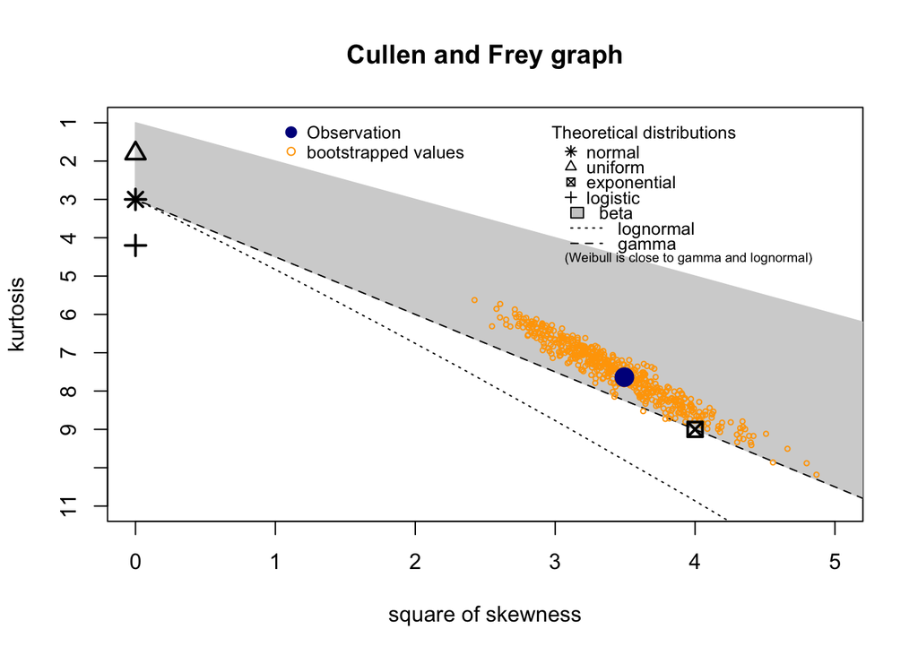

```
## summary statistics
## ------
## min:  7.814454e-05   max:  4.074644
## median:  0.3493946
## mean:  0.5142143
## estimated sd:  0.5135656
## estimated skewness:  1.869442
## estimated kurtosis:  7.637877
```

```r
library(fitdistrplus)
descdist(x[,1], discrete=FALSE, boot=500)
```

It seems that it can be a gamma, or an exponential (not a beta, since the values are not inside [0,1]).

```r
fit1_gamma <- fitdist(x[,1], "gamma")
summary(fit1_gamma)
```

```
## Fitting of the distribution ' gamma ' by maximum likelihood
## Parameters :
##        estimate Std. Error
## shape 0.9900823 0.02463536
## rate  1.9255047 0.06158986
## Loglikelihood:  -837.1315   AIC:  1678.263   BIC:  1689.911
## Correlation matrix:
##           shape      rate
## shape 1.0000000 0.7778981
## rate  0.7778981 1.0000000
```

```r
## Fitting of the distribution ' gamma ' by maximum likelihood
## Parameters :
##        estimate Std. Error
## shape 0.9900823 0.02463536
## rate  1.9255047 0.06158986
## Loglikelihood:  -837.1315   AIC:  1678.263   BIC:  1689.911
## Correlation matrix:
##           shape      rate
## shape 1.0000000 0.7778981
## rate  0.7778981 1.0000000
fit1_exp   <- fitdist(x[,1], "exp")
summary(fit1_exp)
```

```
## Fitting of the distribution ' exp ' by maximum likelihood
## Parameters :
##      estimate Std. Error
## rate 1.944714 0.03889428
## Loglikelihood:  -837.2121   AIC:  1676.424   BIC:  1682.248
```

```r
## Fitting of the distribution ' exp ' by maximum likelihood
## Parameters :
##      estimate Std. Error
## rate 1.944714 0.03889428
## Loglikelihood:  -837.2121   AIC:  1676.424   BIC:  1682.248
```

Both fits are similar. Notice that the real marginal for `x[,1]` is an exponential with `rate=2` which is found by the second fit. Doing the same for `x[,2]`:

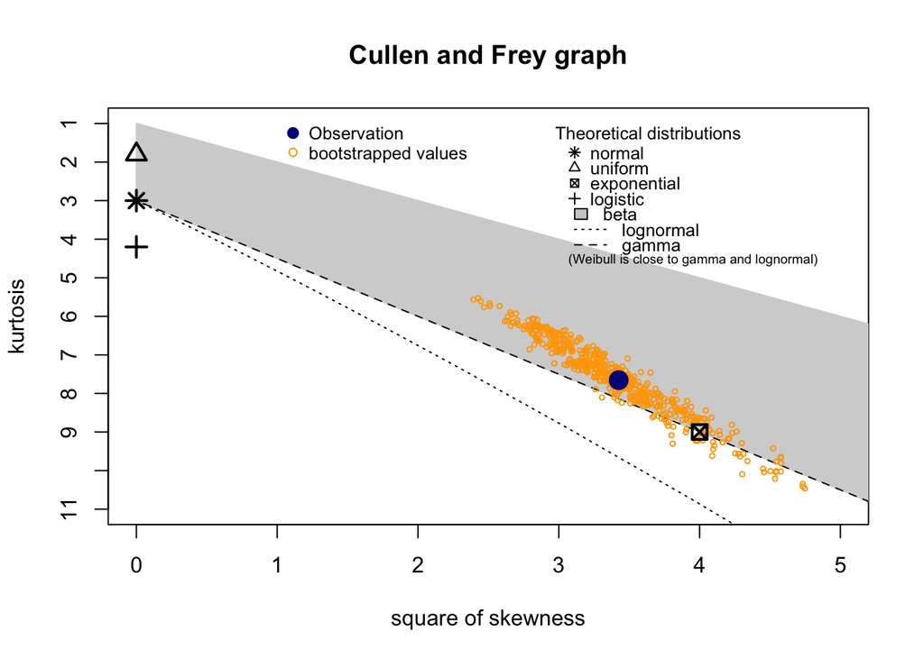

```
## summary statistics
## ------
## min:  8.861588e-06   max:  2.122285
## median:  0.1708639
## mean:  0.2528367
## estimated sd:  0.252168
## estimated skewness:  1.850827
## estimated kurtosis:  7.656177
```

```r
descdist(x[,2], discrete=FALSE, boot=500)
```

```r
fit2_gamma <- fitdist(x[,2], "gamma")
summary(fit2_gamma)
```

```
## Fitting of the distribution ' gamma ' by maximum likelihood
## Parameters :
##        estimate Std. Error
## shape 0.9881979 0.02458431
## rate  3.9084348 0.12505086
## Loglikelihood:  937.6411   AIC:  -1871.282   BIC:  -1859.634
## Correlation matrix:
##           shape      rate
## shape 1.0000000 0.7775534
## rate  0.7775534 1.0000000
```

```r
fit2_exp   <- fitdist(x[,2], "exp")
summary(fit2_exp)
```

```
## Fitting of the distribution ' exp ' by maximum likelihood
## Parameters :
##      estimate Std. Error
## rate 3.955121 0.07910242
## Loglikelihood:  937.5282   AIC:  -1873.056   BIC:  -1867.232
```

Say we pick the gamma for the first, and the exponential for the second:

```r
param1_shape <- fit1_gamma$estimate['shape']
param1_rate  <- fit1_gamma$estimate['rate']
param2_rate  <- fit2_exp$estimate['rate']
```

We can create our proposed copula:

```r
param_gumbelCop <- fitCopula$par

estCop <- mvdc(copula=gumbelCopula(param_gumbelCop,dim=2),
               margins=c("gamma","exp"),
               paramMargins=list(list(shape=param1_shape, rate=param1_rate),
                                 list(rate=param2_rate)))
```

And make a sample to compare if it is similar to the original data:

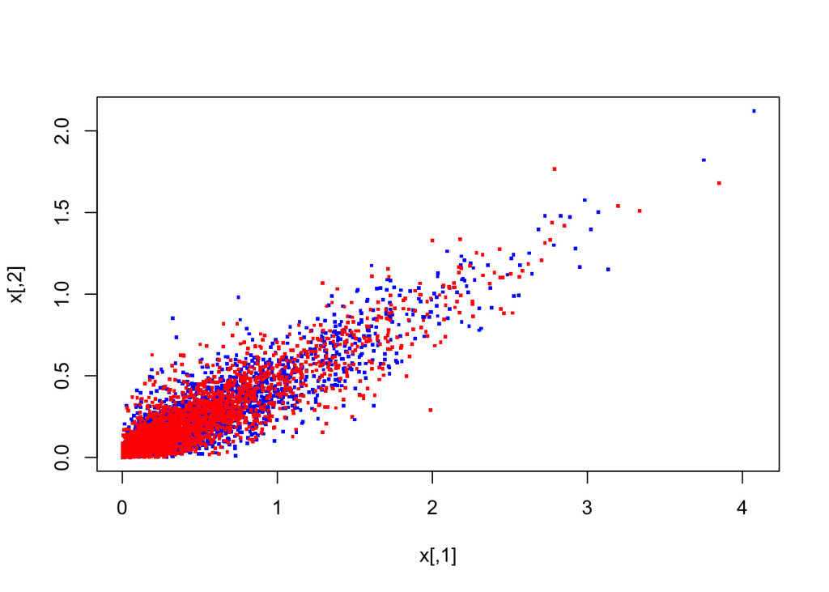

```r
new_data <- rMvdc(2500, estCop)

plot(x, pch='.', col="blue", cex=3)
points(new_data, pch='.', col="red", cex=3)
```